# White Wine Analysis

Abstract

This analysis shall provide exploaratory data analysis for the white wine data set. It includes different 4898 observation for white wine samples. a set of different 11 variables about the white wine has been recorded for each sample in addition to wine quality, there is one field for the record indexing. The inputs include objective tests (e.g. PH values) and the output is based on sensory data (median of at least 3 evaluations made by wine experts). Each expert graded the wine quality between 0 (very bad) and 10 (very excellent).

Library and Dataset Preparations

```
## [1] "D:/DAND/P6_Explore and Summarize Dat/Project"
```

```
## [1] "ggpairs.JPG"           "projecttemplate.rmd"   "projecttemplate2.html"
## [4] "projecttemplate2.rmd"  "prosperLoanData.csv"   "wineQualityInfo.txt"
## [7] "wineQualityWhites.csv"
```

```
## 'data.frame':    4898 obs. of  13 variables:
##  $ X                   : int  1 2 3 4 5 6 7 8 9 10 ...
##  $ fixed.acidity       : num  7 6.3 8.1 7.2 7.2 8.1 6.2 7 6.3 8.1 ...
##  $ volatile.acidity    : num  0.27 0.3 0.28 0.23 0.23 0.28 0.32 0.27 0.3 0.22 ...
##  $ citric.acid         : num  0.36 0.34 0.4 0.32 0.32 0.4 0.16 0.36 0.34 0.43 ...
##  $ residual.sugar      : num  20.7 1.6 6.9 8.5 8.5 6.9 7 20.7 1.6 1.5 ...
##  $ chlorides           : num  0.045 0.049 0.05 0.058 0.058 0.05 0.045 0.045 0.049 0.044 ...
##  $ free.sulfur.dioxide : num  45 14 30 47 47 30 30 45 14 28 ...
##  $ total.sulfur.dioxide: num  170 132 97 186 186 97 136 170 132 129 ...
##  $ density             : num  1.001 0.994 0.995 0.996 0.996 ...
##  $ pH                  : num  3 3.3 3.26 3.19 3.19 3.26 3.18 3 3.3 3.22 ...
##  $ sulphates           : num  0.45 0.49 0.44 0.4 0.4 0.44 0.47 0.45 0.49 0.45 ...
##  $ alcohol             : num  8.8 9.5 10.1 9.9 9.9 10.1 9.6 8.8 9.5 11 ...
##  $ quality             : int  6 6 6 6 6 6 6 6 6 6 ...
```

All data fields are num so no categorical variables availble in the original dataset.

```r
summary(ww)
```

```
##        X        fixed.acidity    volatile.acidity  citric.acid
##  Min.   :   1   Min.   : 3.800   Min.   :0.0800   Min.   :0.0000
##  1st Qu.:1225   1st Qu.: 6.300   1st Qu.:0.2100   1st Qu.:0.2700
##  Median :2450   Median : 6.800   Median :0.2600   Median :0.3200
##  Mean   :2450   Mean   : 6.855   Mean   :0.2782   Mean   :0.3342
##  3rd Qu.:3674   3rd Qu.: 7.300   3rd Qu.:0.3200   3rd Qu.:0.3900
##  Max.   :4898   Max.   :14.200   Max.   :1.1000   Max.   :1.6600
##  residual.sugar     chlorides       free.sulfur.dioxide
##  Min.   : 0.600   Min.   :0.00900   Min.   :  2.00
##  1st Qu.: 1.700   1st Qu.:0.03600   1st Qu.: 23.00
##  Median : 5.200   Median :0.04300   Median : 34.00
##  Mean   : 6.391   Mean   :0.04577   Mean   : 35.31
##  3rd Qu.: 9.900   3rd Qu.:0.05000   3rd Qu.: 46.00
##  Max.   :65.800   Max.   :0.34600   Max.   :289.00
##  total.sulfur.dioxide    density             pH          sulphates
##  Min.   :  9.0        Min.   :0.9871   Min.   :2.720   Min.   :0.2200
##  1st Qu.:108.0        1st Qu.:0.9917   1st Qu.:3.090   1st Qu.:0.4100
##  Median :134.0        Median :0.9937   Median :3.180   Median :0.4700
##  Mean   :138.4        Mean   :0.9940   Mean   :3.188   Mean   :0.4898
##  3rd Qu.:167.0        3rd Qu.:0.9961   3rd Qu.:3.280   3rd Qu.:0.5500
##  Max.   :440.0        Max.   :1.0390   Max.   :3.820   Max.   :1.0800
##     alcohol         quality
##  Min.   : 8.00   Min.   :3.000
##  1st Qu.: 9.50   1st Qu.:5.000
##  Median :10.40   Median :6.000
##  Mean   :10.51   Mean   :5.878
##  3rd Qu.:11.40   3rd Qu.:6.000
##  Max.   :14.20   Max.   :9.000
```

Based on the values fields residual.sugar, free.sulfur.dioxide, total.sulfur.dioxide expected to have outliers

# Univariate Plots Section

Exploring the dataset structure

```
##   X fixed.acidity volatile.acidity citric.acid residual.sugar chlorides
## 1 1           7.0             0.27        0.36           20.7     0.045
## 2 2           6.3             0.30        0.34            1.6     0.049
## 3 3           8.1             0.28        0.40            6.9     0.050
## 4 4           7.2             0.23        0.32            8.5     0.058
## 5 5           7.2             0.23        0.32            8.5     0.058
## 6 6           8.1             0.28        0.40            6.9     0.050
##   free.sulfur.dioxide total.sulfur.dioxide density   pH sulphates alcohol
## 1                  45                  170  1.0010 3.00      0.45     8.8
## 2                  14                  132  0.9940 3.30      0.49     9.5
## 3                  30                   97  0.9951 3.26      0.44    10.1
## 4                  47                  186  0.9956 3.19      0.40     9.9
## 5                  47                  186  0.9956 3.19      0.40     9.9
## 6                  30                   97  0.9951 3.26      0.44    10.1
##   quality
## 1       6
## 2       6
## 3       6
## 4       6
## 5       6
## 6       6
```

Input variables (based on physicochemical tests): 1 - fixed acidity (tartaric acid - g / dm^3) 2 - volatile acidity (acetic acid - g / dm^3) 3 - citric acid (g / dm^3) 4 - residual sugar (g / dm^3) 5 - chlorides (sodium chloride - g / dm^3 6 - free sulfur dioxide (mg / dm^3) 7 - total sulfur dioxide (mg / dm^3) 8 - density (g / cm^3) 9 - pH 10 - sulphates (potassium sulphate - g / dm3) 11 - alcohol (% by volume)

Output variable (based on sensory data): 12 - quality (score between 0 and 10)

```r
table(ww$quality)
```

```
##
##    3    4    5    6    7    8    9
##   20  163 1457 2198  880  175    5
```

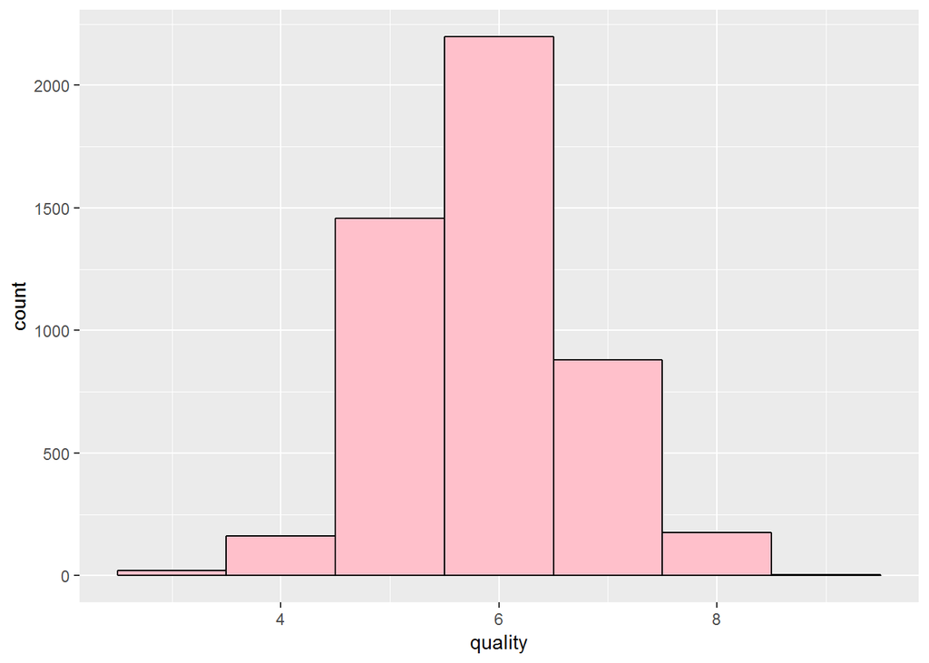

```r
#Exploring quality distribution
ggplot(aes(x = quality), data = ww) +
  geom_histogram(binwidth = 1,color = 'black', fill = 'pink')
```

The wine quality is following a normal distribution with median=6, appears low samples amount for poor and excellent quality as well. Also no samples appear for quality 1, 2 or 10. Based on the discrete distribution of the quality and as I will explore the relationship between it and other variables to I will create an image of it as factor

```r
#change the quality to factor
ww$quality_index <- factor(ww$quality)
str(ww)
```

```
## 'data.frame':    4898 obs. of  14 variables:
##  $ X                   : int  1 2 3 4 5 6 7 8 9 10 ...
##  $ fixed.acidity       : num  7 6.3 8.1 7.2 7.2 8.1 6.2 7 6.3 8.1 ...
##  $ volatile.acidity    : num  0.27 0.3 0.28 0.23 0.23 0.28 0.32 0.27 0.3 0.22 ...
##  $ citric.acid         : num  0.36 0.34 0.4 0.32 0.32 0.4 0.16 0.36 0.34 0.43 ...
##  $ residual.sugar      : num  20.7 1.6 6.9 8.5 8.5 6.9 7 20.7 1.6 1.5 ...
##  $ chlorides           : num  0.045 0.049 0.05 0.058 0.058 0.05 0.045 0.045 0.049 0.044 ...
##  $ free.sulfur.dioxide : num  45 14 30 47 47 30 30 45 14 28 ...
##  $ total.sulfur.dioxide: num  170 132 97 186 186 97 136 170 132 129 ...
##  $ density             : num  1.001 0.994 0.995 0.996 0.996 ...
##  $ pH                  : num  3 3.3 3.26 3.19 3.19 3.26 3.18 3 3.3 3.22 ...
##  $ sulphates           : num  0.45 0.49 0.44 0.4 0.4 0.44 0.47 0.45 0.49 0.45 ...
##  $ alcohol             : num  8.8 9.5 10.1 9.9 9.9 10.1 9.6 8.8 9.5 11 ...
##  $ quality             : int  6 6 6 6 6 6 6 6 6 6 ...
##  $ quality_index       : Factor w/ 7 levels "3","4","5","6",..: 4 4 4 4 4 4 4 4 4 4 ...
```

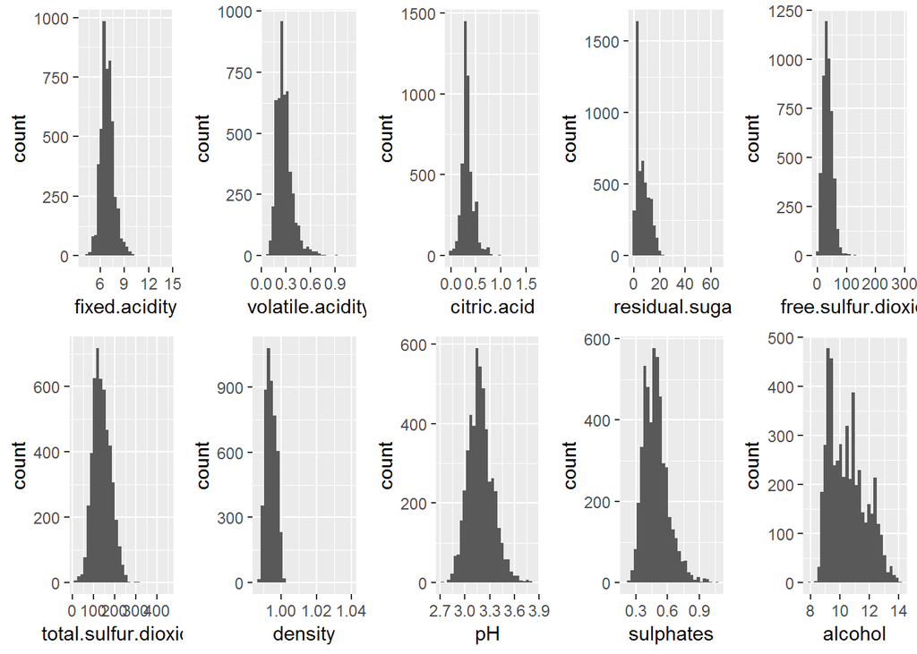

```r
#Exploring some variables

p1= ggplot(aes(x = fixed.acidity), data = ww)+geom_histogram()
p2= ggplot(aes(x = volatile.acidity), data = ww)+geom_histogram()
p3= ggplot(aes(x = citric.acid), data = ww)+geom_histogram()
p4= ggplot(aes(x = residual.sugar), data = ww)+geom_histogram()
p5= ggplot(aes(x =free.sulfur.dioxide), data = ww)+geom_histogram()
p6= ggplot(aes(x =total.sulfur.dioxide), data = ww)+geom_histogram()
p7= ggplot(aes(x =density), data = ww)+geom_histogram()
p8= ggplot(aes(x =pH ), data = ww)+geom_histogram()
p9= ggplot(aes(x =sulphates), data = ww)+geom_histogram()
p10= ggplot(aes(x =alcohol), data = ww)+geom_histogram()

theme_set(theme_grey()+theme(plot.background = element_rect(colour = 'white')))
# arrange plots in grid
grid.arrange(p1, p2, p3,p4,p5,p6,p7,p8,p9,p10, ncol=5,nrow=2)
```

Based on the histogram plot: Fixed.acidity –>normal distribution with few outliers volatile.acidity –> normal distribution with few outliers citric.acidity –> normal distribution with few outliers residual.sugar –> not a normal distribution as peak at small value with few outliers free.sulfur.dioxide –> normal distribution with few outliers total.sulfur.dioxide –> normal distribution with few outliers density –> normal distribution with few outliers pH –> normal distribution sulphates –> normal distribution alcohol –> not a normal distribution as many modes are appearing

```r
table(ww$fixed.acidity)
```

```
##
##  3.8  3.9  4.2  4.4  4.5  4.6  4.7  4.8  4.9    5  5.1  5.2  5.3  5.4  5.5
##    1    1    2    3    1    1    5    9    7   24   23   28   27   28   31
##  5.6  5.7  5.8  5.9    6  6.1 6.15  6.2  6.3  6.4 6.45  6.5  6.6  6.7  6.8
##   71   88  121  103  184  155    2  192  188  280    1  225  290  236  308
##  6.9    7  7.1 7.15  7.2  7.3  7.4  7.5  7.6  7.7  7.8  7.9    8  8.1  8.2
##  241  232  200    2  206  178  194  123  153   93   93   74   80   56   56
##  8.3  8.4  8.5  8.6  8.7  8.8  8.9    9  9.1  9.2  9.3  9.4  9.5  9.6  9.7
##   52   35   32   25   15   18   16   17    6   21    3   11    2    5    4
##  9.8  9.9   10 10.2 10.3 10.7 11.8 14.2
##    8    2    3    1    2    2    1    1
```

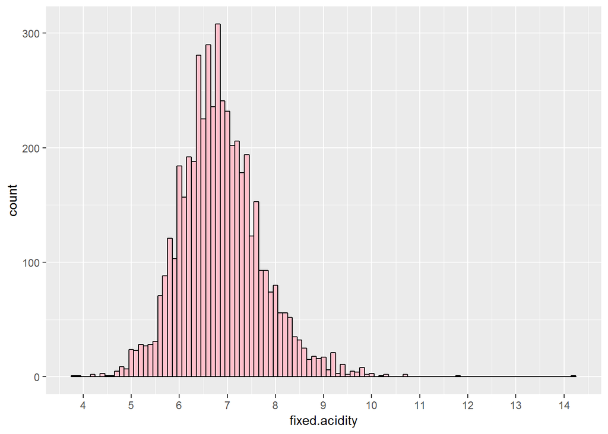

```r
#Exploring fixed.acidity distribution
ggplot(aes(x = fixed.acidity), data = ww) +
  geom_histogram(binwidth = 0.1,color = 'black', fill = 'pink')+
  scale_x_continuous(breaks=3:15)
```

fixed.acidity distribution are having normal distribution mainly values are between 5 & 9 so in following graph I am replotting the distribution while zooming on the 99% percent samples to remove samples with extreme high value.

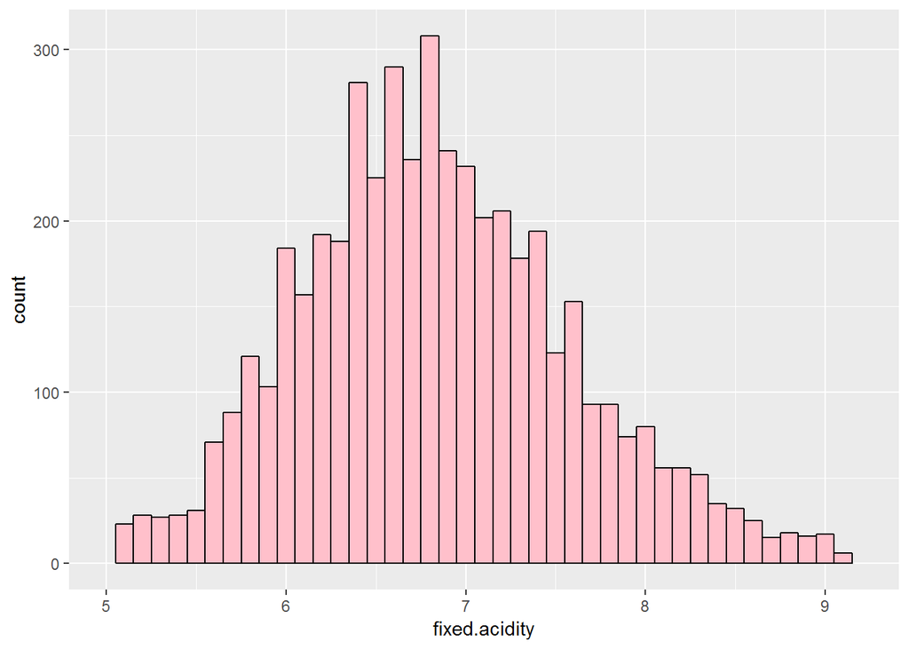

```r
#remove fixed.acidity lowest and highest 1% sample

ggplot(aes(x = fixed.acidity), data = ww) +
  geom_histogram(binwidth = 0.1,color = 'black', fill = 'pink')+
  scale_x_continuous(breaks=3:15)+
  xlim(quantile(ww$fixed.acidity,0.01),quantile(ww$fixed.acidity,0.99))
```

```r
table(ww$pH)
```

```
##
## 2.72 2.74 2.77 2.79  2.8 2.82 2.83 2.84 2.85 2.86 2.87 2.88 2.89  2.9 2.91
##    1    1    1    3    3    1    4    1    9    9    9   11   17   31   15
## 2.92 2.93 2.94 2.95 2.96 2.97 2.98 2.99    3 3.01 3.02 3.03 3.04 3.05 3.06
##   18   38   35   26   63   32   41   68   74   49   68   78   97   89  115
## 3.07 3.08 3.09  3.1 3.11 3.12 3.13 3.14 3.15 3.16 3.17 3.18 3.19  3.2 3.21
##   79  136   92  135  126  134  117  172  136  164  124  138  145  137   95
## 3.22 3.23 3.24 3.25 3.26 3.27 3.28 3.29  3.3 3.31 3.32 3.33 3.34 3.35 3.36
##  146  116  132  114   96   88   87   82   93   79   86   49   79   48   83
## 3.37 3.38 3.39  3.4 3.41 3.42 3.43 3.44 3.45 3.46 3.47 3.48 3.49  3.5 3.51
##   49   58   40   39   30   48   20   33   17   28   21   21   23   15   14
## 3.52 3.53 3.54 3.55 3.56 3.57 3.58 3.59  3.6 3.61 3.62 3.63 3.64 3.65 3.66
##   17   13   14    9    8    5    5    6    7    3    1    6    2    4    5
## 3.67 3.68 3.69  3.7 3.72 3.74 3.75 3.76 3.77 3.79  3.8 3.81 3.82
##    1    2    2    1    3    2    2    2    2    1    2    1    1
```

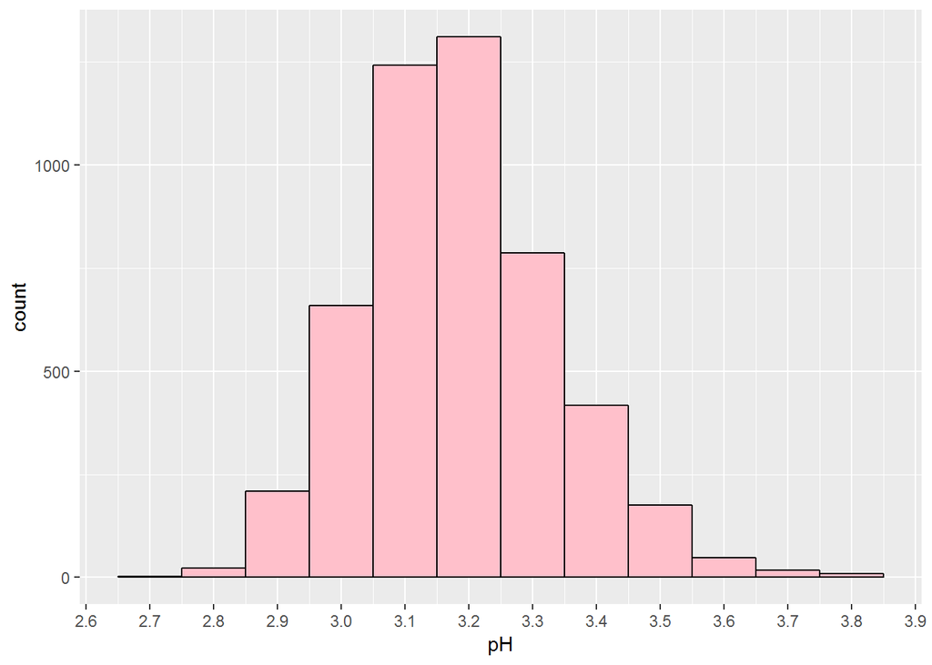

```r
ggplot(aes(x = pH), data = ww) +
  geom_histogram(binwidth = 0.1,color = 'black', fill = 'pink')+
  scale_x_continuous(breaks=seq(2.5,4,0.1))
```

pH distribution are having normal distribution, values are between 2.72 & 3.82 so in following graph I am replotting the distribution while changing the bin size to get better visibity on value distribution, no outliers appearing for pH.

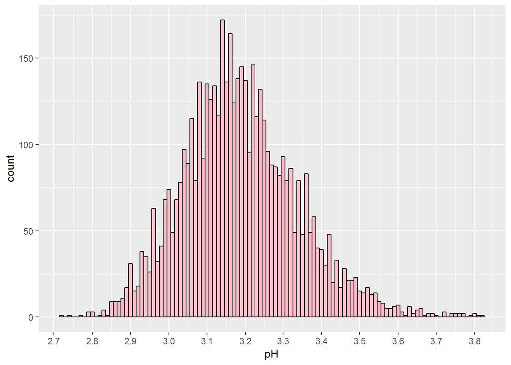

```r
ggplot(aes(x = pH), data = ww) +
  geom_histogram(binwidth = 0.01,color = 'black', fill = 'pink')+
  scale_x_continuous(breaks=seq(2.5,4,0.1))
```

After the bin size reduction for pH, still the distribution maintaining the approximate normal distribution with median 3.18.

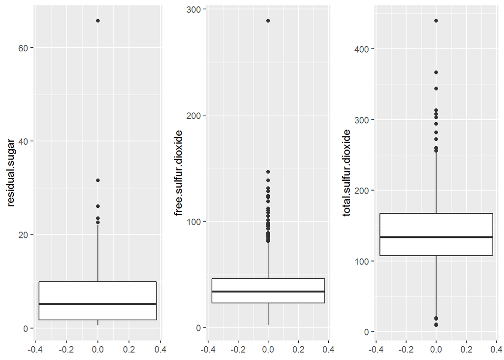

```r
#box plot for fields I beleive to have many outliers
#fields: fields residual.sugar, free.sulfur.dioxide, total.sulfur.dioxide

p1=ggplot(aes(y = residual.sugar), data = ww) +
  geom_boxplot()

p2=ggplot(aes(y = free.sulfur.dioxide), data = ww) +
  geom_boxplot()

p3=ggplot(aes(y = total.sulfur.dioxide), data = ww) +
  geom_boxplot()


# arrange plots in grid
grid.arrange(p1, p2, p3, ncol=3)
```

I used the box plot to verify the outliers in the 3 variables residual.sugar, free.sulfur.dioxide, total.sulfur.dioxide. residual.sugar: only few observations are considered outliers in the increasing side from the median free.sulfur.dioxide:many observations are considered outliers in the increasing side from the median total.sulfur.dioxide:many observations are considered outliers in both sides from the median

# Univariate Analysis

### What is the structure of your dataset?

My dataset has 4898 observation for white wine samples with 12 different variables

### What is/are the main feature(s) of interest in your dataset?

The wine quality is the main features along with different 11 attributes

### What other features in the dataset do you think will help support your investigation into your feature(s) of interest? I will explore the 11 attributes to check if they have relation with the wine quality

### Did you create any new variables from existing variables in the dataset?

Yes, I created one factor transformation for the quality

### Of the features you investigated, were there any unusual distributions? Did you perform any operations on the data to tidy, adjust, or change the form of the data? If so, why did you do this?

This dataset appears to be relatively simple not high percentage or outliers or missing values. The quality is a discrete value and also based on human measurement so may have some bias so would prefer dealing with it a categorical value so I made a copy of it as factor. 3 fields are having clear outliers residual.sugar, free.sulfur.dioxide, total.sulfur.dioxide

# Bivariate Plots Section

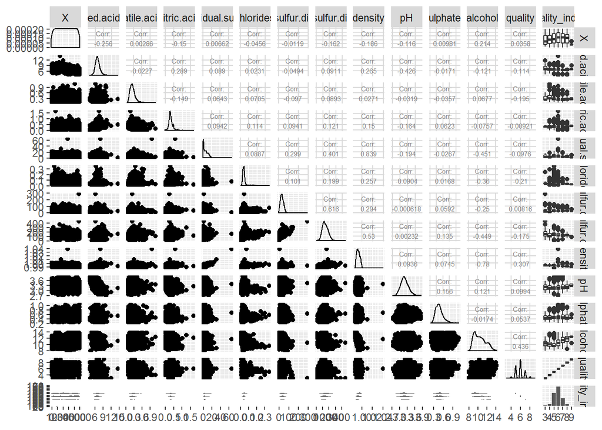

```r
ggpairs(ww,progress=FALSE,upper = list(continuous = wrap("cor", size = 2)))
```

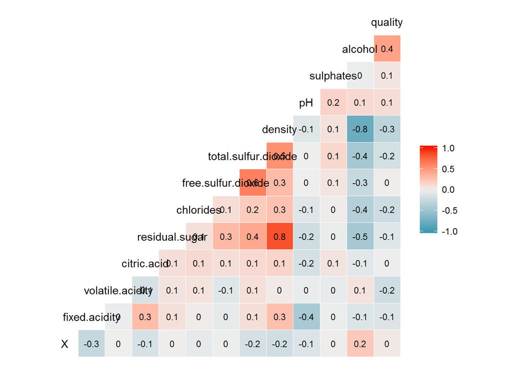

```r
ggcorr(ww,digits=2,label = TRUE,label_size=3)
```

As shown based on correlation factor, we can see 6 different ranges: -0.3–>0, 0–>0.3: no correlation or poor correlation relation -0.7–>-0.3, 0.3–>0.7: medium correlation relation -1 –>-0.7, 0.7 –>1: strong correlation relation the negative sign refer to inverse relation while the positive refer to positive relation

We can then state the negative strong relations: density and alcohol:-0.8

Medium relation example: residual.sugar and total.sulfur.dioxide:0.4 residual.sugar and alcohol:-0.5

for the quality we have medium positive relation with alcohol and medium negative relation with density

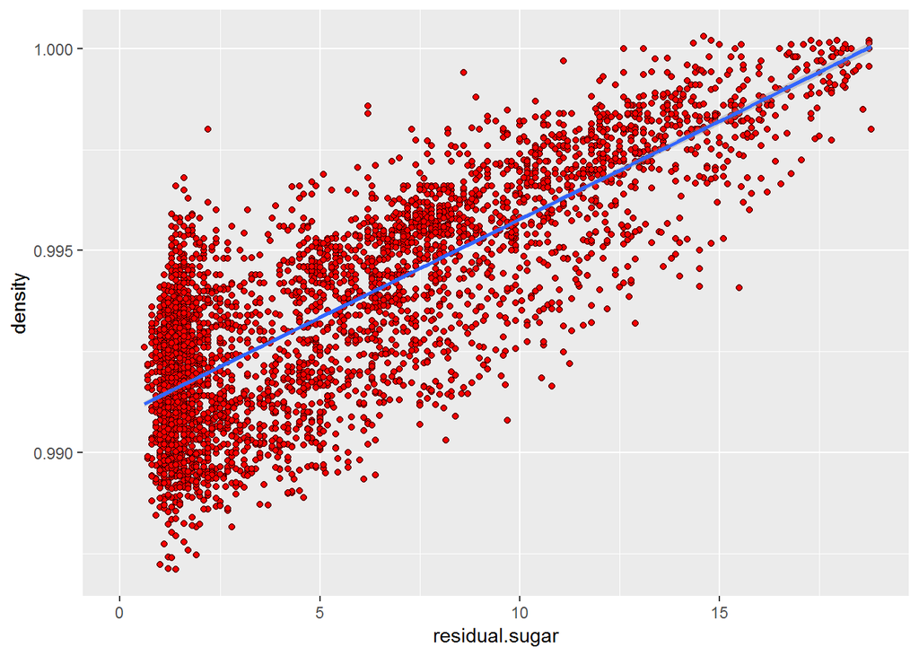

```r
#plotting strong relation between residual.sugar and density
ggplot(aes(x=residual.sugar,y=density),data=ww)+
  geom_point(fill=I('red'),color='black',shape=21)+
  xlim(0,quantile(ww$residual.sugar,0.99))+
  ylim(0.9871,quantile(ww$density,0.99))+
  stat_smooth(method = 'lm')
```

strong positive relation between residual.sugar and density

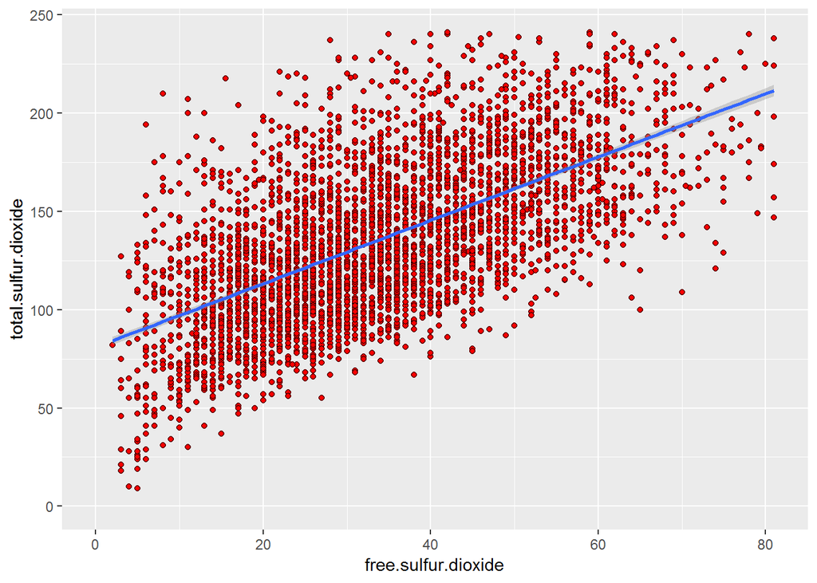

```r
#plotting strong relation between free.sulfur.dioxide and total.sulfur.dioxide
ggplot(aes(x=free.sulfur.dioxide,y=total.sulfur.dioxide),data=ww)+
  geom_point(fill=I('red'),color='black',shape=21)+
  xlim(0,quantile(ww$free.sulfur.dioxide,0.99))+
  ylim(0,quantile(ww$total.sulfur.dioxide,0.99))+
  stat_smooth(method = 'lm')
```

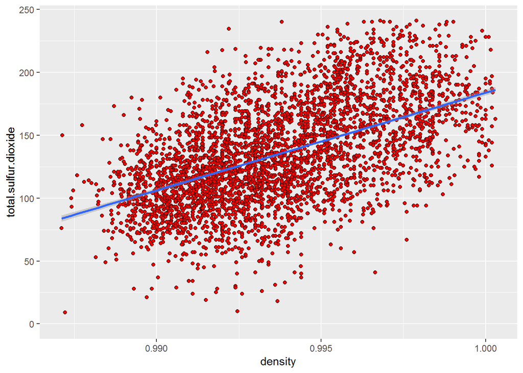

```r
#plotting strong relation between density and total.sulfur.dioxide
ggplot(aes(x=density,y=total.sulfur.dioxide),data=ww)+
  geom_point(fill=I('red'),color='black',shape=21)+
  xlim(0.9871,quantile(ww$density,0.99))+
  ylim(0,quantile(ww$total.sulfur.dioxide,0.99))+
  stat_smooth(method = 'lm')
```

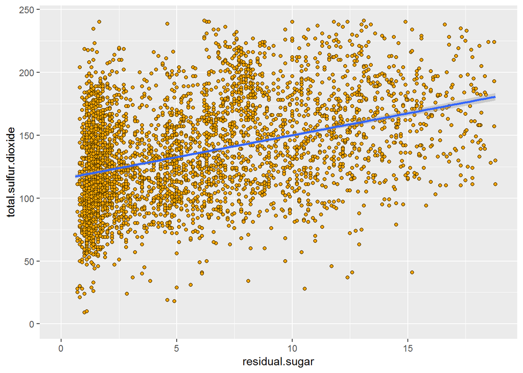

```r
#plotting medium relation between residual.sugar and total.sulfur.dioxide
ggplot(aes(x=residual.sugar,y=total.sulfur.dioxide),data=ww)+
  geom_point(fill=I('orange'),color='black',shape=21)+
  xlim(0,quantile(ww$residual.sugar,0.99))+
  ylim(0,quantile(ww$total.sulfur.dioxide,0.99))+
  stat_smooth(method = 'lm')
```

medium positive relation between residual.sugar and total.sulfur.dioxide

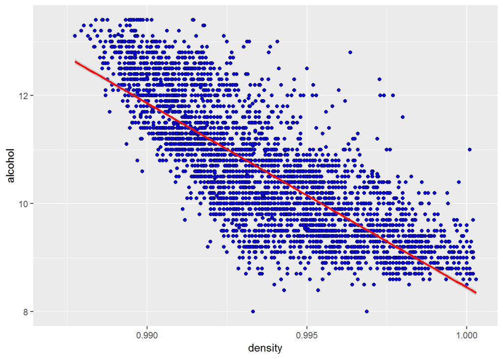

```r
#plotting strong relation between density and alcohol
ggplot(aes(x=density,y=alcohol),data=ww)+
  geom_point(fill=I('blue'),color='black',shape=21)+
  xlim(0.9871,quantile(ww$density,0.99))+
  ylim(min(ww$alcohol),quantile(ww$alcohol,0.99))+
  stat_smooth(method = 'lm',color='red')
```

strong negative relation between density and alcohol

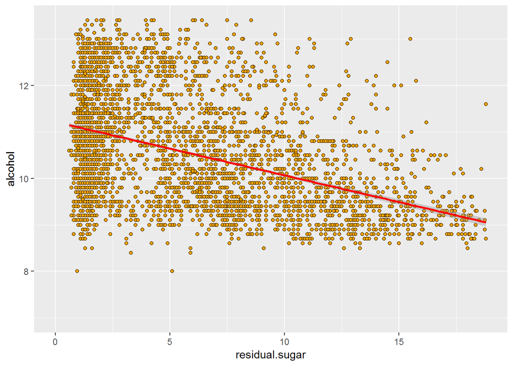

```r
#plotting medium relation between residual.sugar and alcohol
ggplot(aes(x=residual.sugar,y=alcohol),data=ww)+
  geom_point(fill=I('orange'),color='black',shape=21)+
  xlim(0,quantile(ww$residual.sugar,0.99))+
  ylim(7,quantile(ww$alcohol,0.99))+
  stat_smooth(method = 'lm',color='red')
```

medium negative relation between residual.sugar and alcohol

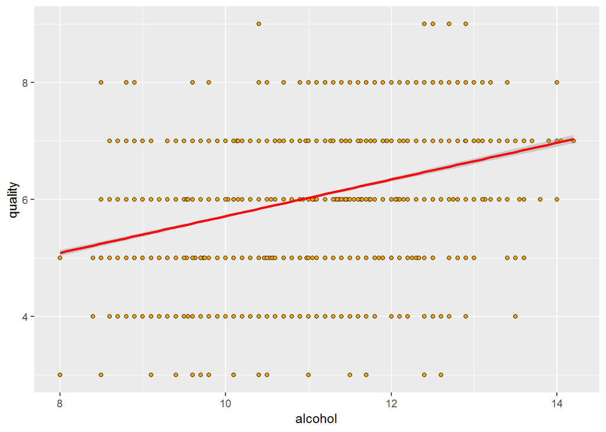

```r
#plotting medium relation between quality and alcohol
ggplot(aes(x=alcohol,y=quality),data=ww)+
  geom_point(fill=I('orange'),color='black',shape=21)+
  stat_smooth(method = 'lm',color='red')
```

medium positive relation between quality and alcohol

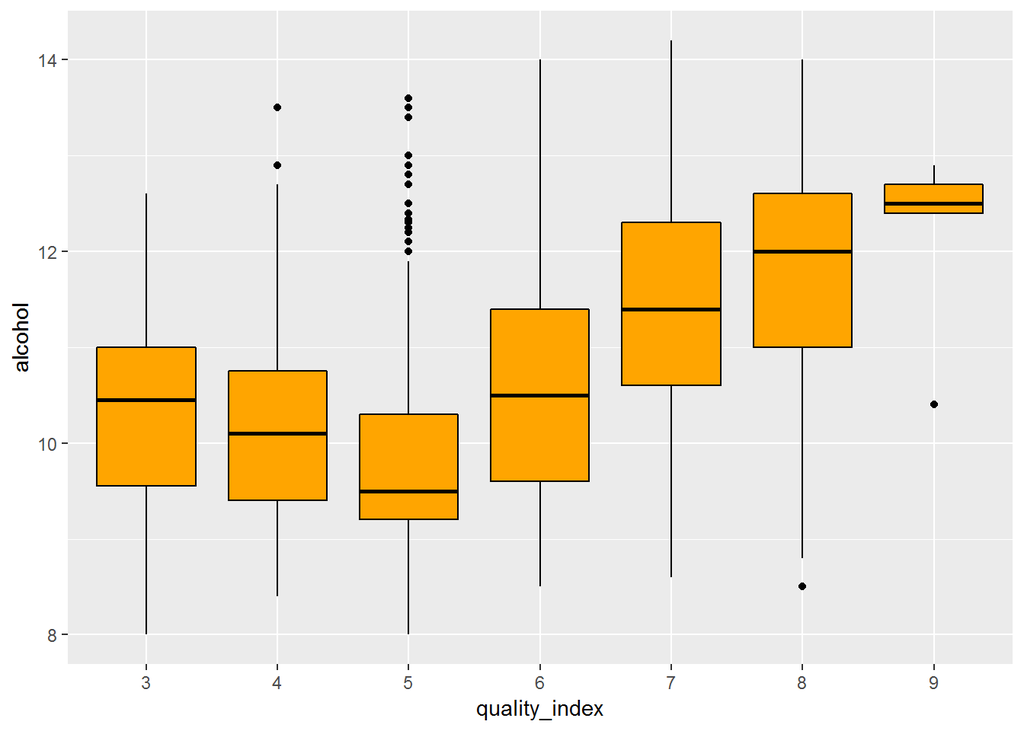

```r
#plotting medium relation between quality and alcohol
ggplot(aes(x=quality_index,y=alcohol),data=ww)+
  geom_boxplot(fill=I('orange'),color='black',shape=19)
```

From the box plot it appears the median for the alcohol increase with quality except for quality 3 and 4 however as the number of samples is small so potential bias may exist so I will narrow down the quality from 10 category into 3 as it is easy for drinks to have opinion bad,normal,good so will create quality.bucket to group the samples into 3 different categories

```r
#Narrow the quality to 3 categories to minimize the samples distribution variation

ww$quality.bucket <- cut(ww$quality,labels = c('Low','Medium','High'),
                             c(1,5.9,6.1,10))
table(ww$quality.bucket)
```

```
##
##    Low Medium   High
##   1640   2198   1060
```

Now the distribution of samples into 3 categories is more balanced and would be used in the coming analysis.

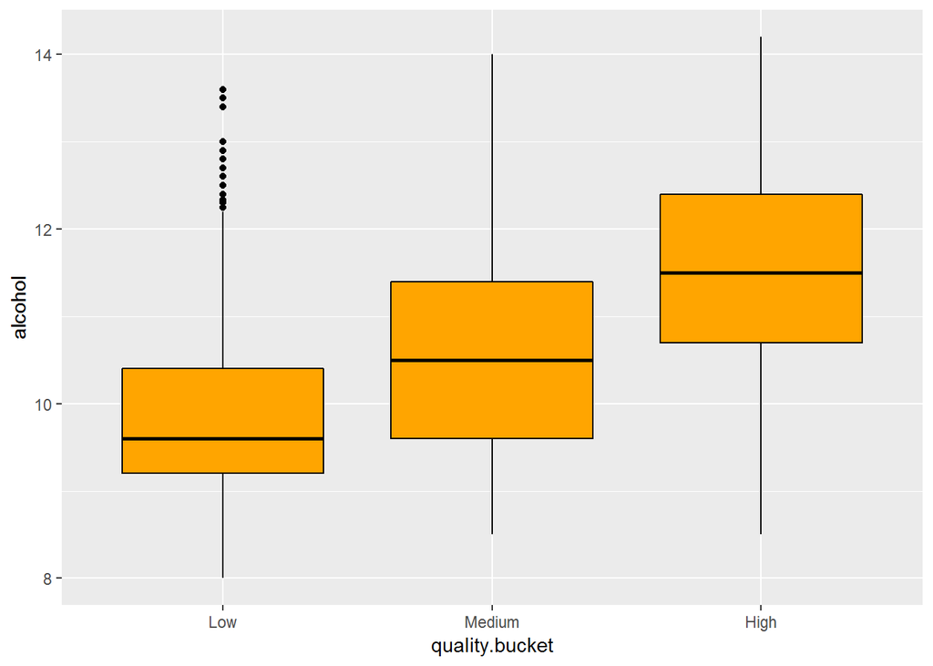

```r
#plotting relation between quality bucket and alcohol
ggplot(aes(x=quality.bucket,y=alcohol),data=ww)+
  geom_boxplot(fill=I('orange'),color='black',shape=19)
```

Now appear more relationship, so on average the increase of alcohol increase the wine quality

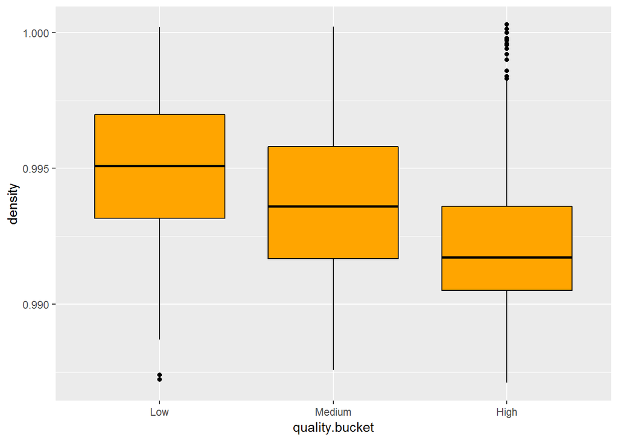

```r
#plotting relation between quality bucket and density
ggplot(aes(x=quality.bucket,y=density),data=ww)+
  geom_boxplot(fill=I('orange'),color='black',shape=19)+
  ylim(0.9871,quantile(ww$density,0.99))
```

Doing similar exploratory between the density and quality.bucket, so on average the increase of density reduce the wine quality and this is expected.

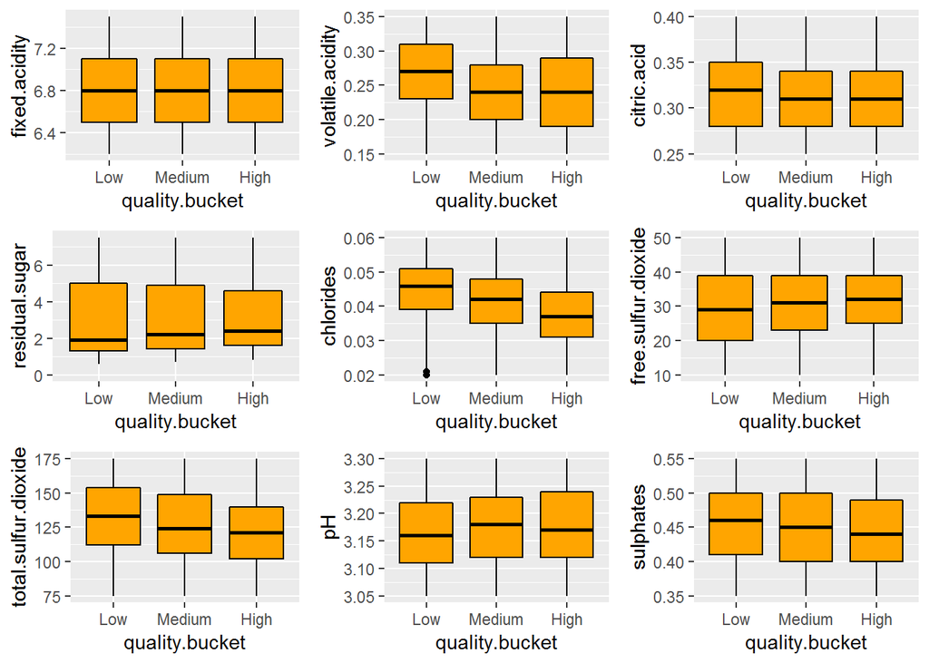

```r
#chekother fields relationship with quality.bucket
p1 = ggplot(aes(x=quality.bucket,y=fixed.acidity),data=ww)+
  geom_boxplot(fill=I('orange'),color='black',shape=19) + ylim(6.2,7.5)
p2 = ggplot(aes(x=quality.bucket,y=volatile.acidity),data=ww)+
  geom_boxplot(fill=I('orange'),color='black',shape=19) + ylim(0.15,0.35)
p3 = ggplot(aes(x=quality.bucket,y=citric.acid),data=ww)+
  geom_boxplot(fill=I('orange'),color='black',shape=19) + ylim(0.25,0.4)
p4 = ggplot(aes(x=quality.bucket,y=residual.sugar),data=ww)+
  geom_boxplot(fill=I('orange'),color='black',shape=19) + ylim(0,7.5)
p5 = ggplot(aes(x=quality.bucket,y=chlorides),data=ww)+
  geom_boxplot(fill=I('orange'),color='black',shape=19) + ylim(0.02,0.06)
p6 = ggplot(aes(x=quality.bucket,y=free.sulfur.dioxide),data=ww)+
  geom_boxplot(fill=I('orange'),color='black',shape=19) + ylim(10,50)
p7 = ggplot(aes(x=quality.bucket,y=total.sulfur.dioxide),data=ww)+
  geom_boxplot(fill=I('orange'),color='black',shape=19) + ylim(75,175)
p8 = ggplot(aes(x=quality.bucket,y=pH ),data=ww)+
  geom_boxplot(fill=I('orange'),color='black',shape=19) + ylim(3.05,3.3)
p9 = ggplot(aes(x=quality.bucket,y=sulphates),data=ww)+
  geom_boxplot(fill=I('orange'),color='black',shape=19) + ylim(0.35,0.55)

grid.arrange(p1, p2, p3,p4,p5,p6,p7,p8,p9, ncol=3,nrow=3)
```

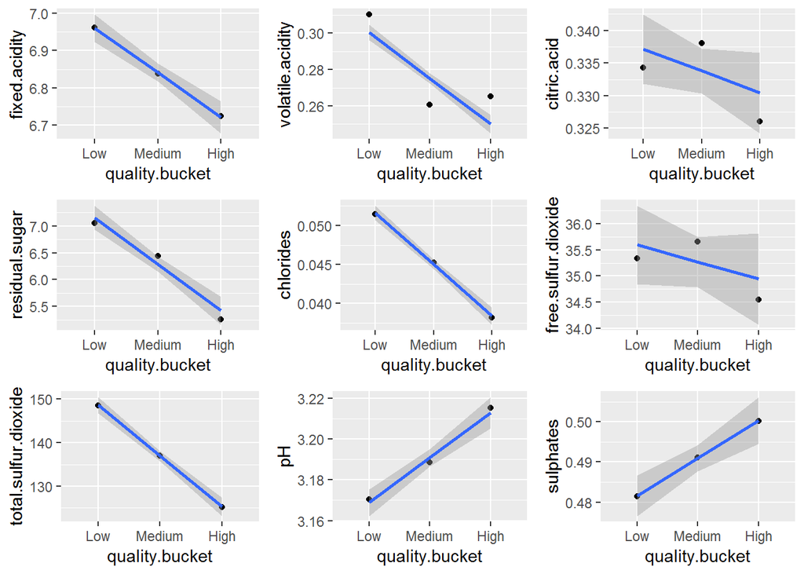

```r
#chekother fields relationship with quality.bucket
p1 = ggplot(aes(x=quality.bucket,y=fixed.acidity,group = 1),data=ww)+
  geom_point(stat='summary',fun.y=mean) + stat_smooth(aes(group = 1), method = "lm")
p2 = ggplot(aes(x=quality.bucket,y=volatile.acidity,group = 1),data=ww)+
  geom_point(stat='summary',fun.y=mean) + stat_smooth(aes(group = 1), method = "lm")
p3 = ggplot(aes(x=quality.bucket,y=citric.acid,group = 1),data=ww)+
  geom_point(stat='summary',fun.y=mean) + stat_smooth(aes(group = 1), method = "lm")
p4 = ggplot(aes(x=quality.bucket,y=residual.sugar,group = 1),data=ww)+
  geom_point(stat='summary',fun.y=mean) + stat_smooth(aes(group = 1), method = "lm")
p5 = ggplot(aes(x=quality.bucket,y=chlorides,group = 1),data=ww)+
  geom_point(stat='summary',fun.y=mean) + stat_smooth(aes(group = 1), method = "lm")
p6 = ggplot(aes(x=quality.bucket,y=free.sulfur.dioxide,group = 1),data=ww)+
  geom_point(stat='summary',fun.y=mean) + stat_smooth(aes(group = 1), method = "lm")
p7 = ggplot(aes(x=quality.bucket,y=total.sulfur.dioxide,group = 1),data=ww)+
  geom_point(stat='summary',fun.y=mean) + stat_smooth(aes(group = 1), method = "lm")
p8 = ggplot(aes(x=quality.bucket,y=pH ,group = 1),data=ww)+
  geom_point(stat='summary',fun.y=mean) + stat_smooth(aes(group = 1), method = "lm")
p9 = ggplot(aes(x=quality.bucket,y=sulphates,group = 1),data=ww)+
  geom_point(stat='summary',fun.y=mean) + stat_smooth(aes(group = 1), method = "lm")

grid.arrange(p1, p2, p3,p4,p5,p6,p7,p8,p9, ncol=3,nrow=3)
```

Creating more clear graph to join the mean of variables by the quality.bucket to figure out is the quality is direct/inverse trending with the different variables and what direct trending with quality.bucket: pH, sulphates inverse trending with quality.bucket: fixed.acidity, residual.sugar,chlorides, total.sulfur.dioxide no relationship with quality.bucket: volatile.acidity, citric.acidity, free.sulfur.dioxide

# Bivariate Analysis

### Talk about some of the relationships you observed in this part of the investigation. How did the feature(s) of interest vary with other features in the dataset?

As per the correlation matrix, we can see 6 different ranges: -0.3–>0, 0–>0.3: no correlation or poor correlation relation -0.7–>-0.3, 0.3–>0.7: medium correlation relation -1 –>-0.7, 0.7 –>1: strong correlation relation the negative sign refer to inverse relation while the positive refer to positive relation

We can then state the negative strong relations: density and alcohol:-0.8

Medium relation example: residual.sugar and total.sulfur.dioxide:0.4 residual.sugar and alcohol:-0.5

for the quality we have medium positive relation with alcohol and medium negative relation with density

### Did you observe any interesting relationships between the other features (not the main feature(s) of interest)? I analyse all relations as above stated

### What was the strongest relationship you found?

# Multivariate Plots Section

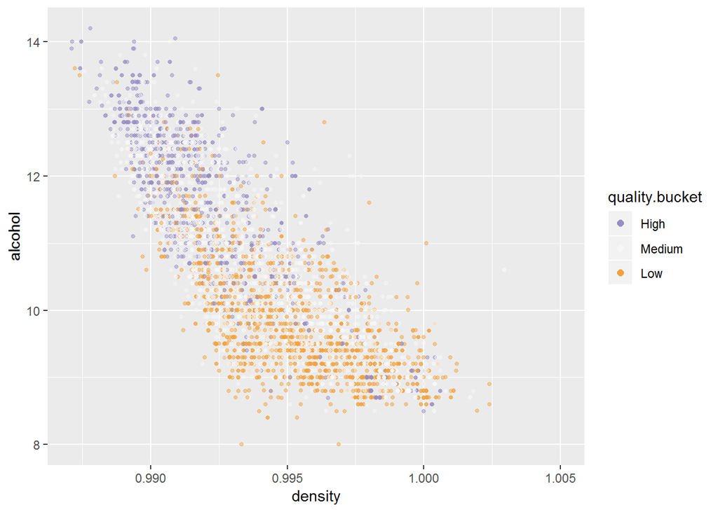

```r
ggplot(aes(y = alcohol, x = density,color=quality.bucket), data = ww) +
  geom_point(alpha = 0.5, size = 1, position = 'jitter')+
  xlim(min(ww$density),1.005)+
  scale_color_brewer(type = 'div',palette = 4,
                     guide = guide_legend(title = 'quality.bucket', reverse = T,
                                          override.aes = list(alpha = 1, size = 2)))
```

Here I am figuring out 2 variables distribution and if this will give better distribution for the quality.buket. It is shown from the distribution that the high quality wine are having high alcohol and less density value

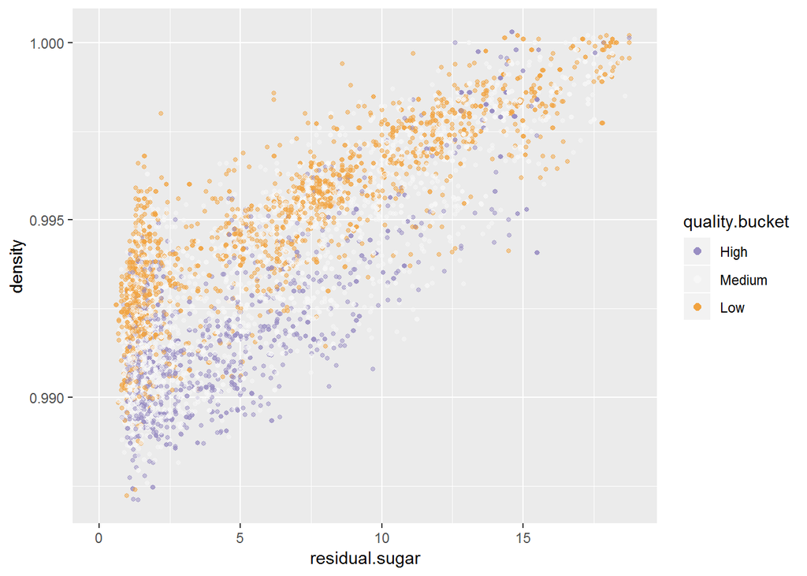

```r
ggplot(aes(x=residual.sugar,y=density,color=quality.bucket), data = ww) +
  geom_point(alpha = 0.5, size = 1, position = 'jitter')+
  xlim(0,quantile(ww$residual.sugar,0.99))+
  ylim(0.9871,quantile(ww$density,0.99))+
  scale_color_brewer(type = 'div',palette = 4,
                     guide = guide_legend(title = 'quality.bucket', reverse = T,
                                          override.aes = list(alpha = 1, size = 2)))
```

Here I am figuring out 2 variables distribution and if this will give better distribution for the quality.buket. It is shown from the distribution that the high quality wine are in the lower portion of the samples having lower residual sugar and lower density.

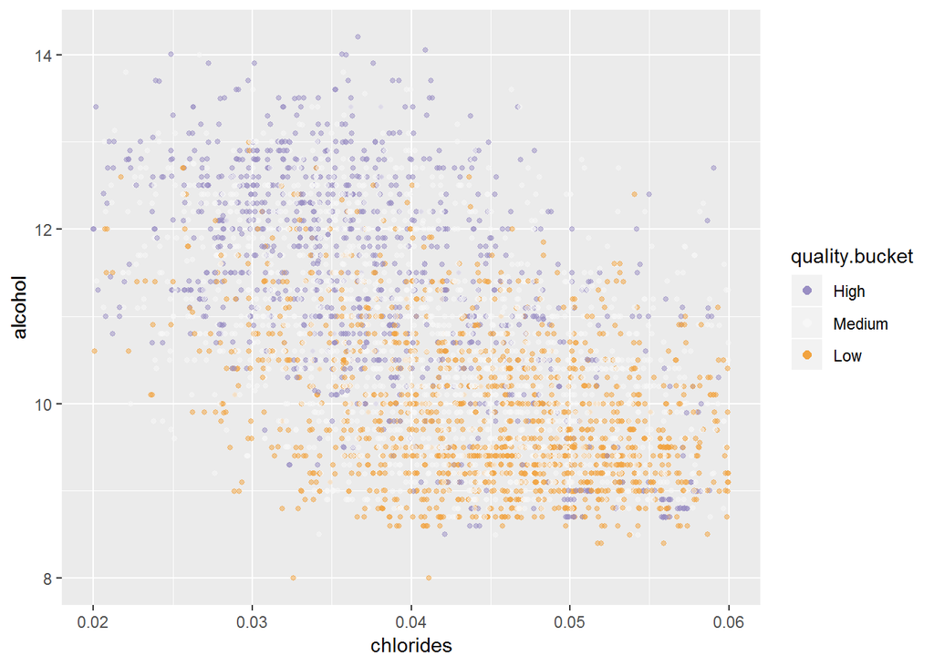

```r
ggplot(aes(y = alcohol, x = chlorides,color=quality.bucket), data = ww) +
  geom_point(alpha = 0.5, size = 1, position = 'jitter')+
  xlim(0.02,0.06)+
  scale_color_brewer(type = 'div',palette = 4,
                     guide = guide_legend(title = 'quality.bucket', reverse = T,
                                          override.aes = list(alpha = 1, size = 2)))
```

Here I am figuring out 2 variables distribution and if this will give better distribution for the quality.buket. It is shown from the distribution that the high quality wine are in the upper portion of the samples having lower chlorides and higher alcohol.

# Multivariate Analysis

### Talk about some of the relationships you observed in this part of the investigation. Were there features that strengthened each other in terms of looking at your feature(s) of interest?

the high quality wine are having high alcohol and less density value and lower clorides

### Were there any interesting or surprising interactions between features?

No

### OPTIONAL: Did you create any models with your dataset? Discuss the There is no strong correlation between variables and the quality so any built model will have big errors exceeding 50%

# Final Plots and Summary

### Plot One

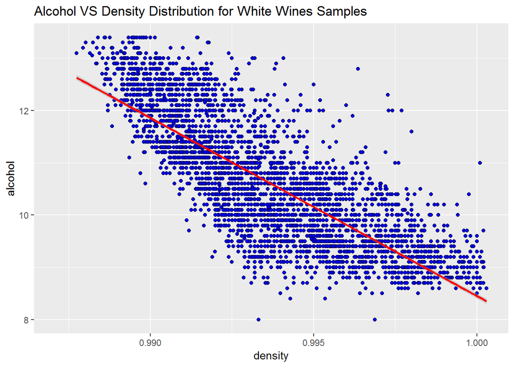

### Description One

There is strong negative relation between density and alcohol for the white wine samples which means the more the alcohol amount in the wine sample the less density it would have

### Plot Two

[figure not shown]

### Description Two

The graph joins the mean of variables by the quality.bucket to figure out is the quality is direct/inverse trending with the different variables and what direct trending with quality.bucket: pH, sulphates inverse trending with quality.bucket: fixed.acidity, residual.sugar,chlorides, total.sulfur.dioxide no relationship with quality.bucket: volatile.acidity, citric.acidity, free.sulfur.dioxide

### Plot Three

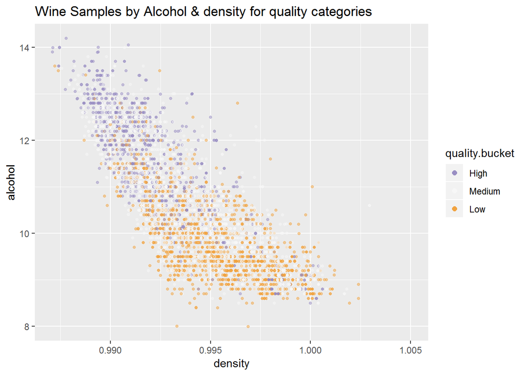

## Based on the alcohol and density distribution ,the high quality wine are having high alcohol and less density value.

# Reflection

It was interesting to study the different content of wine and impact on the quality, we get some insights about main components and its impact on the recorded quality. My concern is that there are 2 other factors: the crapes type (manufature time, source country) as well as the experts information (age group, sex, nationality) as this would bias their judgement as well.